# Numerical quantity perceived from the data graphics

Mahbubul Majumder, PhD  
Feb 27, 2019

### Numerical summary of data

- Measures of center
  - mean
  - median
  - mode
  - quartiles/percentiles
- Measures of dispersion
  - Range
  - Variance and standard deviation
  - IQR
- Other measures
  - skewness
  - kurtosis
  - correlation/ linearity
  - trend/ slope
- Comparisons
  - differences in all the measures
  - proportions and ratios
  - spatial relations
  - grouping/ classification

### Bar plot

- what do we get from this plot?
- we perceive
  - proportion of users
  - differences

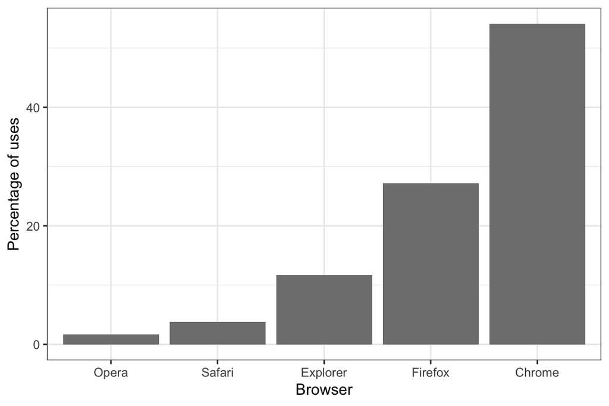

### Pie chart

- what do we get from this plot?
- we perceive
  - proportion of users
  - differences
  - chrome is larger than all others combined

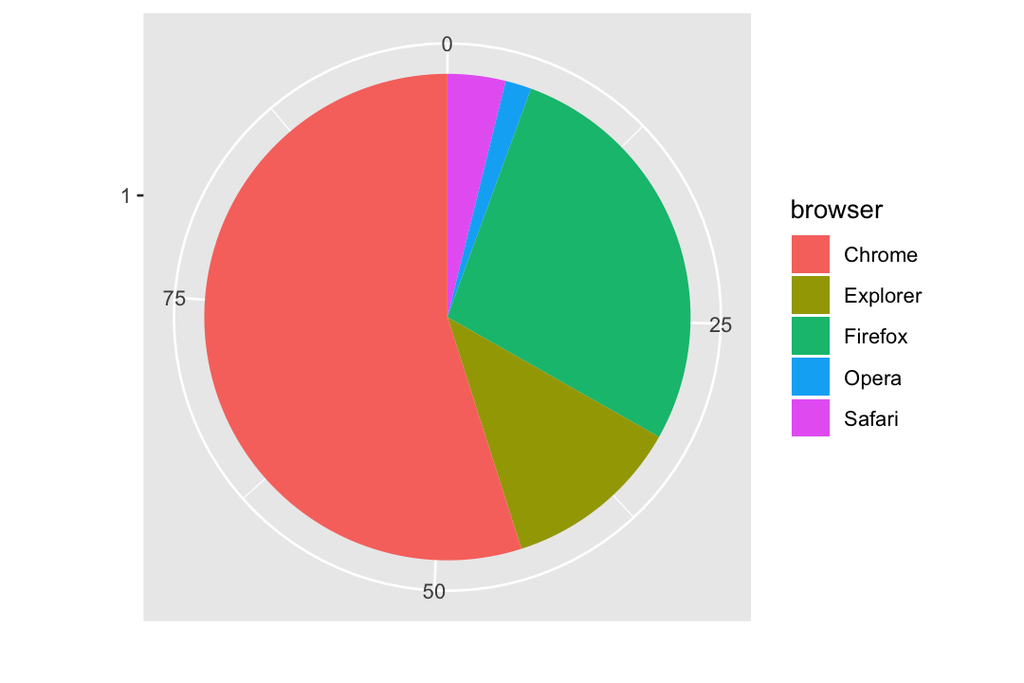

### Dot plot

- what do we get from this plot?
- we perceive
  - skewness
  - center
  - spread
  - outlier

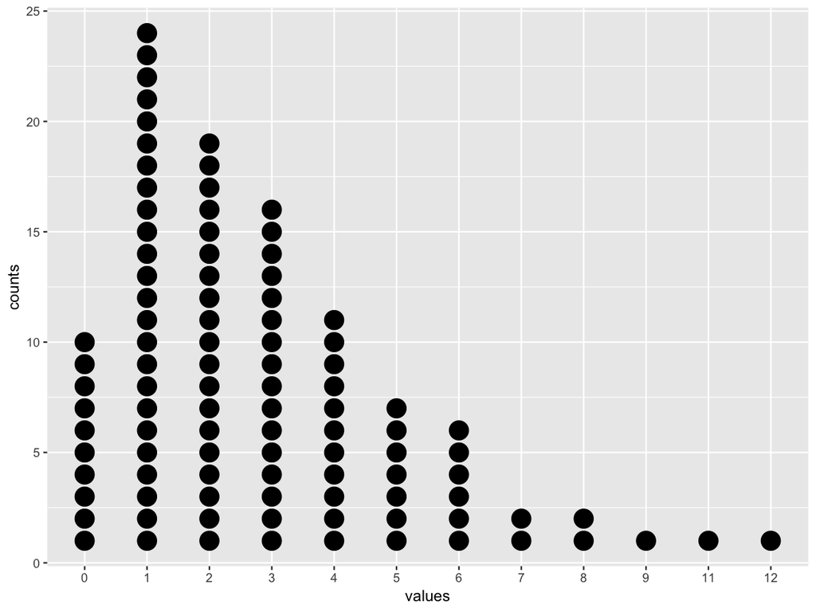

### Histogram

- what do we get from this plot?
- we perceive
  - skewness
  - center
  - spread
  - outlier

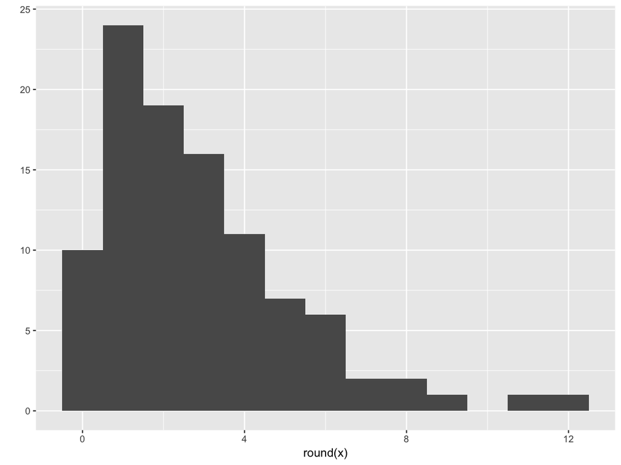

### Boxplot and violin plot

- what do we get from this plot?
- Boxplot shows
  - skewness
  - center
  - spread
  - outlier
- Violin plot
  - skewness
  - multiple modes

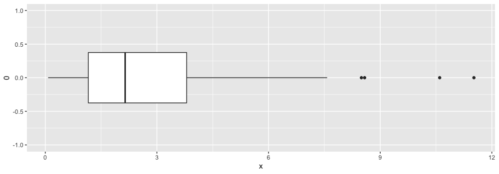

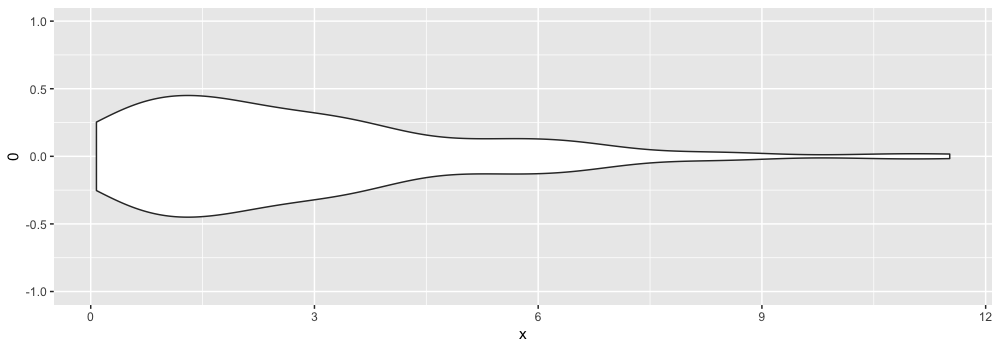

### Line plot

- what do we get from this plot?
- we perceive
  - trend and slope
  - linearity
  - differences
  - sex & year interaction

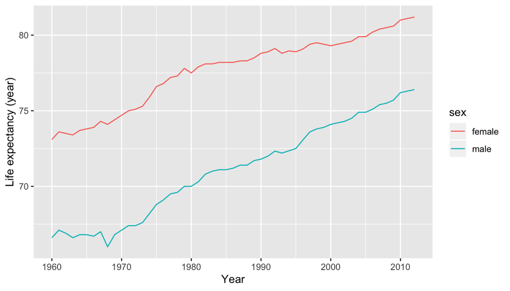

### Faceted line plot

- what do we get from this plot?
- we perceive
  - trend comparisons
  - gender differences
  - sex & year interaction
  - country & year interaction
  - country & sex & year interaction

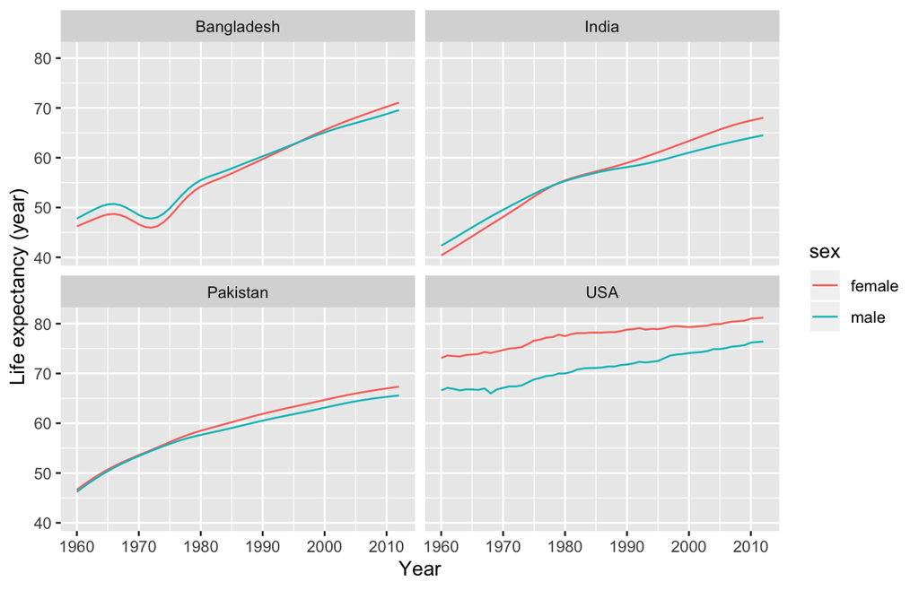

### Mosaic plot

- what do we get from this plot?
- we perceive
  - correlation between two categorical variables
  - proportion within class
  - odds ratio

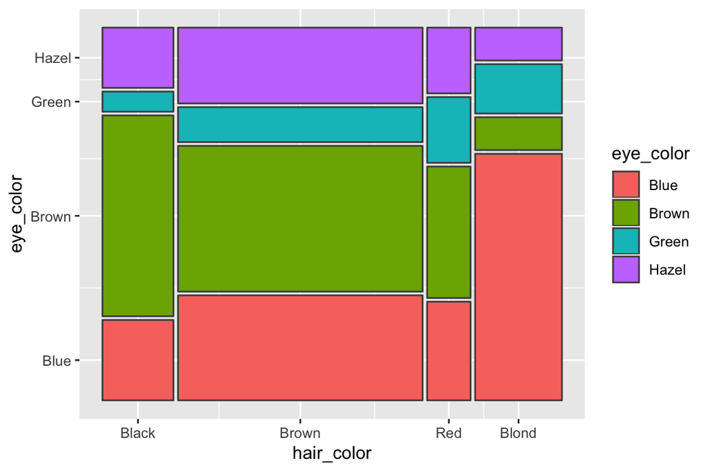

### Mosaic plot and odds ratio

- titanic survival data

```
           0   1
  female 127 339
  male   682 161
```

- survival ratio
  - RF = `339/127` = 2.67
  - RM = `161/682` = 0.24
- odds ratio
  - OR = RF/RM  
    = `(339*682)/(161*127)`  
    = 11.31

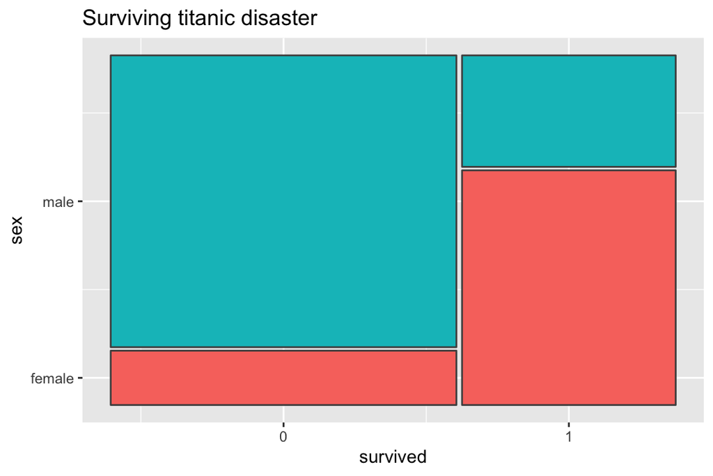

### Scatter plot

- what do we get from this plot?
- we perceive
  - correlation between two continuous variables
  - linearity in relationship

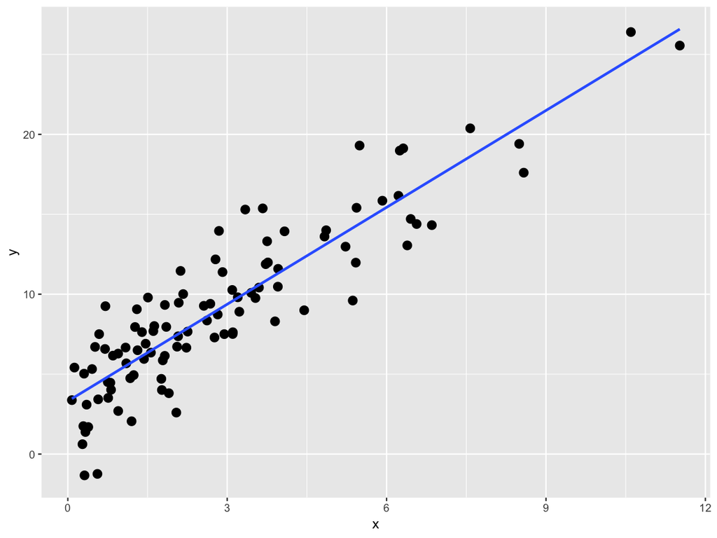

### Multiple density plots

- what do we get from this plot?
- we perceive differences in
  - skewness
  - center
  - spread
  - differences in densities

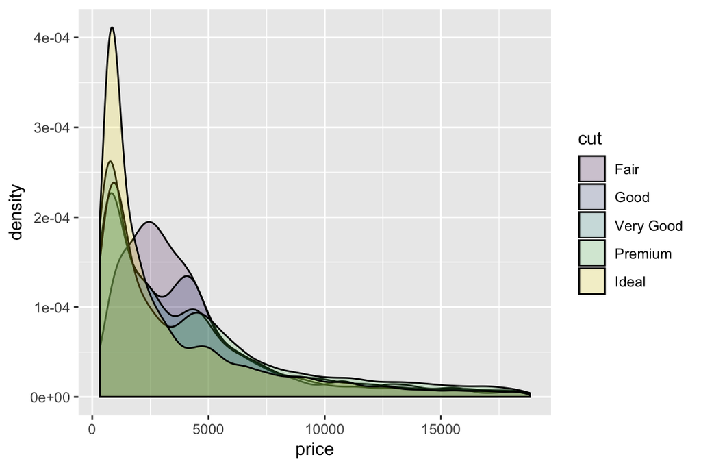

### Side by side box plots

- what do we get from this plot?
- we perceive differences in
  - skewness
  - center
  - spread
  - outlier
  - comparisons

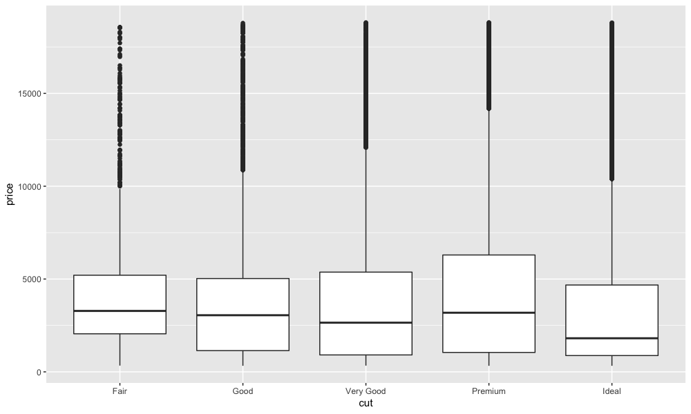

### Side by side violin plots

- what do we get from this plot?
- we perceive differences in
  - skewness
  - center
  - spread
  - outlier
  - comparisons
- some comparisons can't be seen in box plots

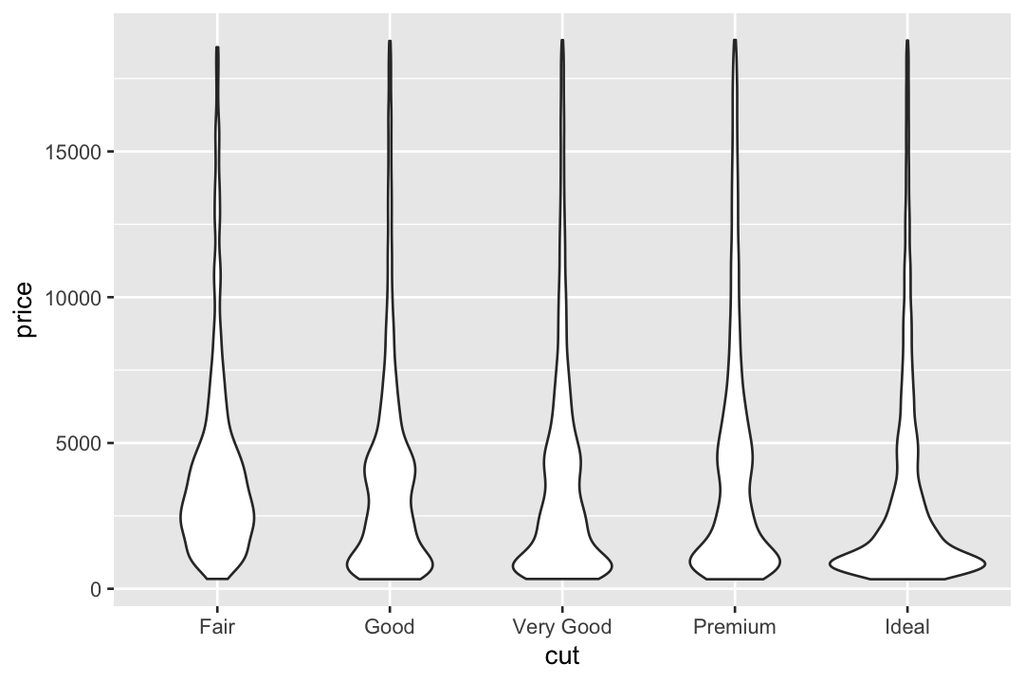

### Facetted maps

- what do we get from this plot?
- we perceive
  - spatial relationship
  - comparisons of types

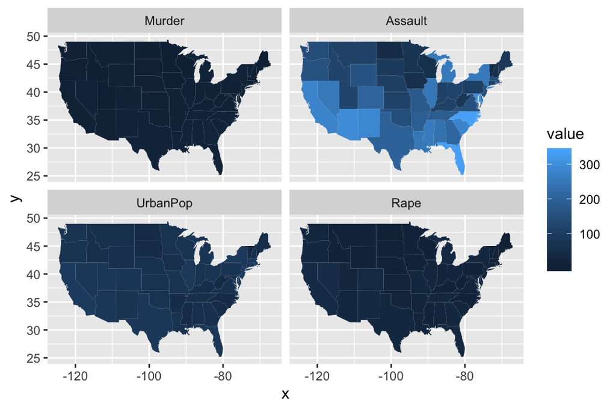

### Time series

- what do we get from this plot?
- we perceive
  - trend over time
  - cyclic variation
  - seasonal variation
  - auto correlation

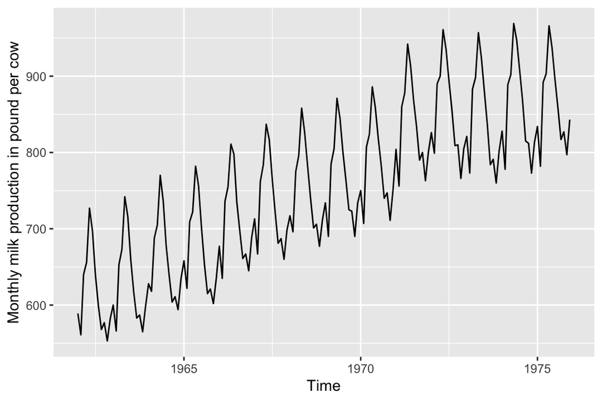

### Parallel coordinate plot

- what do we get from this plot?
- we perceive
  - which variable classify groups
  - relationship between continuous and categorical variables

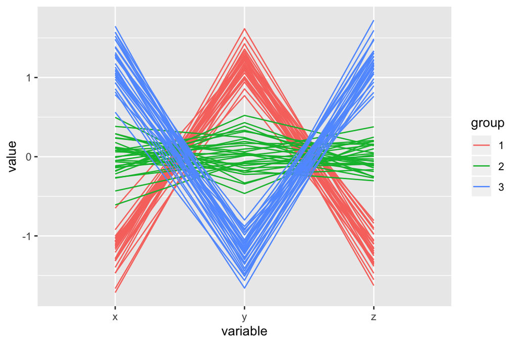

### scatterplot by group

- what do we get from this plot?
- we perceive
  - group distance
  - group-wise variability
  - separation
  - conditional correlation

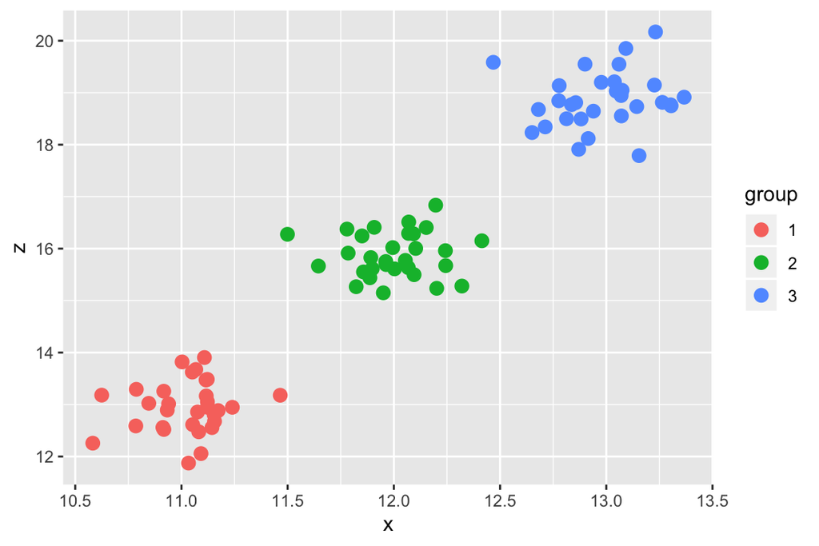

### Convex hull plot

- what do we get from this plot?
- we perceive
  - group distance
  - group-wise variability
  - separation
  - number of group of groups

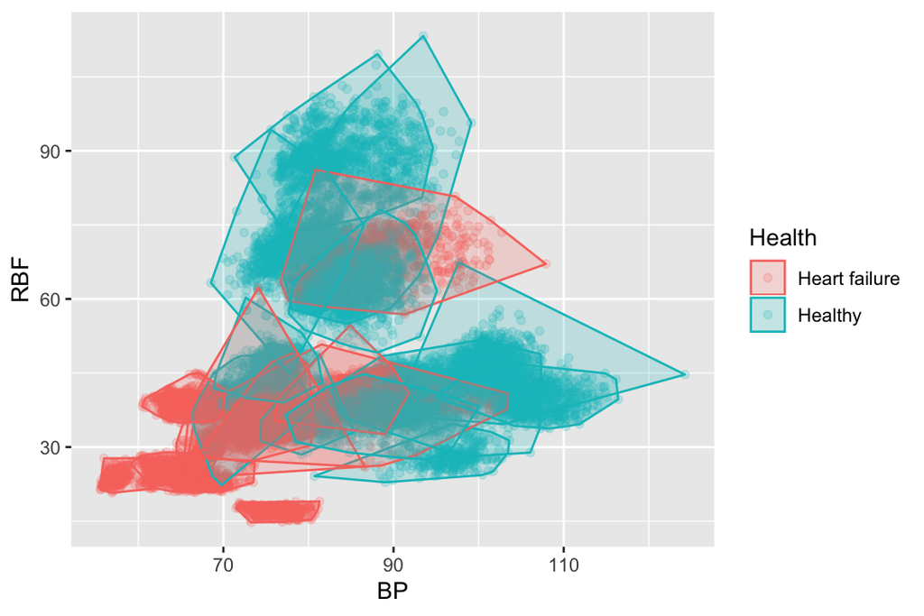

### Contour plot

- what do we get from this plot?
- we perceive
  - location of the peak
  - number of peaks
  - steepness
  - correlation

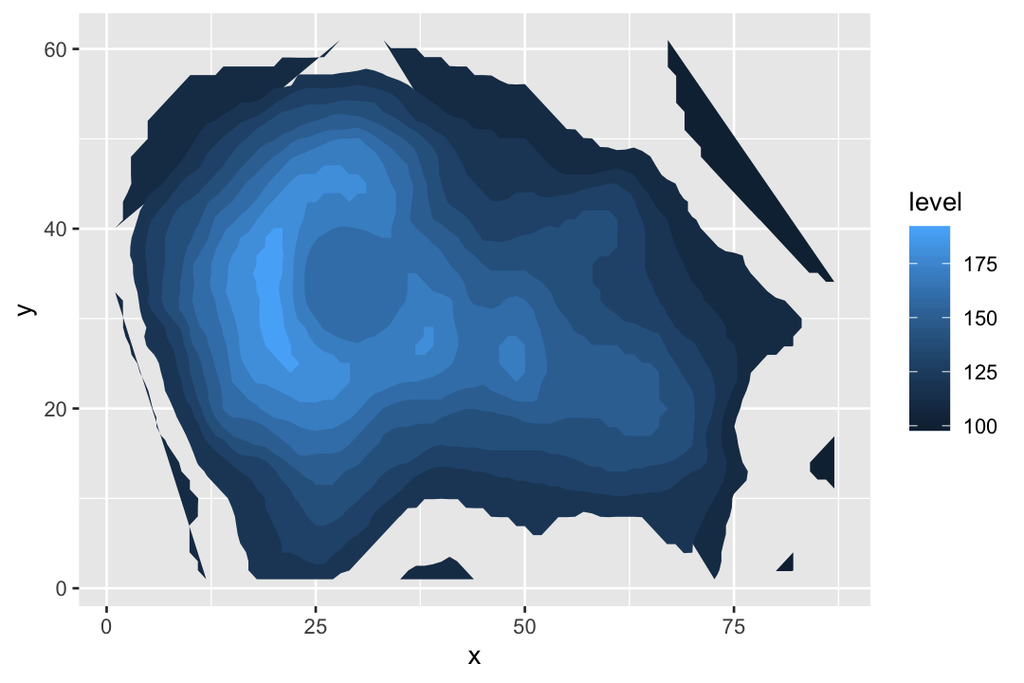

### Step plot

- what do we get from this plot?
- we perceive
  - overall differences in CDF
  - kolmogorov distance
- uses
  - test of normality
  - deviation from certain density

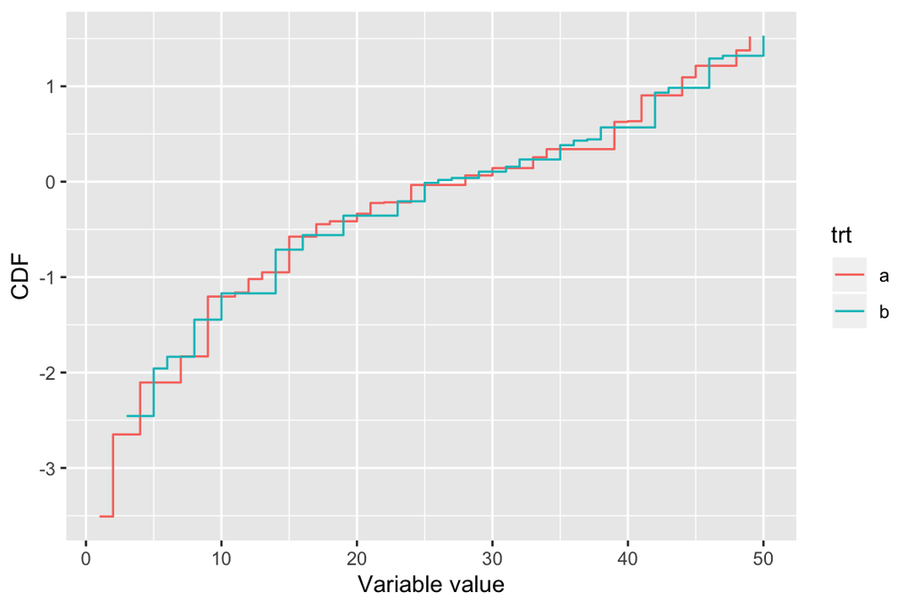

### Network graph

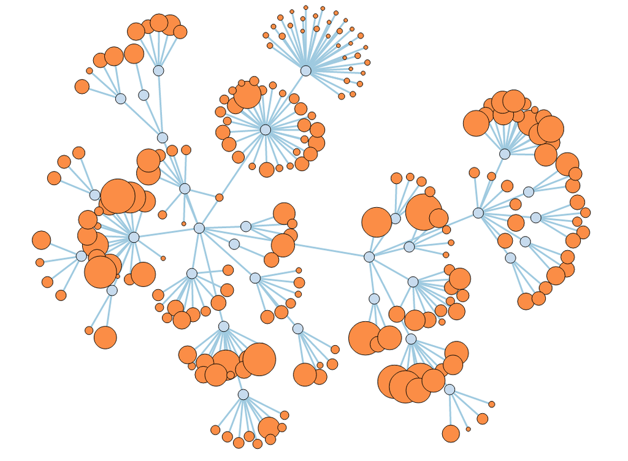

### Reading assignment and references

- For ggplot2 documentation  
  http://docs.ggplot2.org/current/